# Trabalho II Calculo Numerico

Daniel Lopes

2022-11-11

Aluno: Daniel Lopes Toso RA: 236081

Para visualizar o arquivo .rmd com os códigos será necessário o software Rstudio. Para que o código funcione adequadamente no arquivo .rmd, é necessário definir o diretório de trabalho a ser utilizado, para isso: -Abra o RStudio -Abra o arquivo .rmd -Vá em Session -Set working directory -> To source file location

[figure not shown]

O arquivo .rmd será enviado em uma pasta com os demais elementos a serem utilizados, é importante abrir o arquivo dentro da pasta e não retirar nenhum dos demais elementos.

Serão utilizados os pacotes abaixo, o primeiro chunk instala os pacotes e o segundo chama as bibliotecas para o ambiente do rmd.

tidyverse -> manipulação de data frames, gráficos, funções de utilidade geral. readxl -> lê arquivos no formato .xlsx gganimate -> animações em R. gifski -> renderizar animações e salvar em .gif. transformr -> auxilio para animações em R. pracma -> funções matemáticas relacionadas a matrizes, sistemas lineares e sistemas de ODE.

```r
#Retire a hashtag para executar a instalação.
#install.packages("tidyverse")
#install.packages("readxl")
#install.packages("gganimate")
#install.packages("gifski")
#install.packages("pracma")
#install.packages("transformr")
```

```r
library(tidyverse)
library(readxl)
library(gganimate)
library(gifski)
library(pracma)
library(transformr)
```

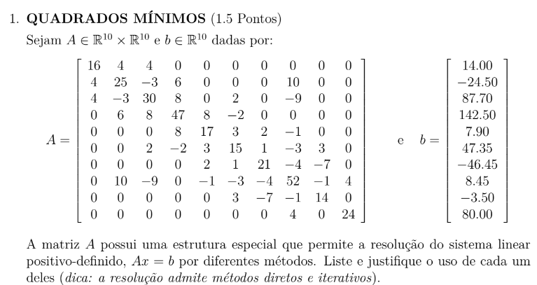

A matriz apresentada possui determinante não nulo, portanto, o sistema tem solução única. Por ser estritamente diagonalmente dominante, é garantida a convergência de diversos métodos iterativos e o bom condicionamento para métodos diretos, o que evita erros de arredondamento.

Métodos Diretos:

-Eliminação de Gauss: O método de eliminação de Gauss aparenta a ser o mais efetivo pois a matriz já é estritamente diagonalmente dominante, então não é necessário pivotear colunas ou linhas, apenas realizar as operações necessárias para transformar a matriz em triangular superior (ou diagonal) e resolve-la.

-Regra de Cramer: A regra de Cramer tem custo computacional de grau n^n, onde n é o tamanho da matriz. Logo, para este caso, iria necessitar de 10 bilhões de operações para sua resolução. Apesar de ser um método direto e relativamente simples de programar, traria um grande custo computacional neste caso.

-Fatoração LU: A fatoração LU possui um custo computacional direcionado ao passo da criação das matrizes que fatoram a matriz original. Logo, para resolver um único sistema de equações, o método não seria apropriado, pois é menos efetivo do que a eliminação de Gauss. Porém, se fosse necessária a resolução do sistema diversas vezes com a mesma matriz A, a fatoração LU teria um custo-benefício superior.

Métodos Iterativos:

-Gauss-Seidel: Como a matriz é estritamente diagonalmente dominante, a convergência para o método de Gauss-Seidel é garantida. Por sua eficiência e facilidade de implementação, é um método iterativo recomendável neste caso.

-Gauss-Jacobi: O método de Gauss-Jacobi tem sua convergência garantida pelo mesmo motivo descrito acima, porém sua eficiência é inferior ao método de Gauss-Seidel, portanto, não é o método ideal para este caso, mas não também não possui pontos negativos.

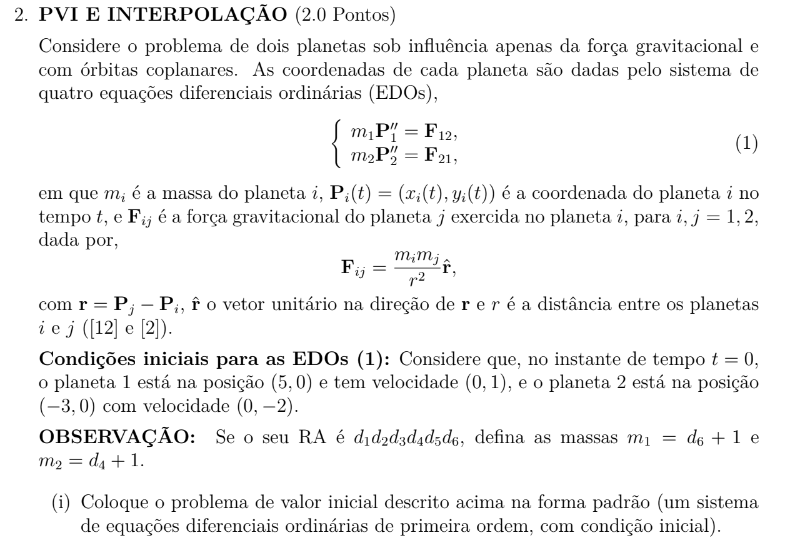

Notando que Xi’ = Vxi e Yi’ = Vyi, podemos construir o vetor Z tal que: Z = [X1, Y1, Vx1, Vy1, X2, Y2, Vx2, Vy2]

Com condição inicial: Z(t(0)) = [5,0,0,1,-3,0,0,-2]

Onde ’ = d/dt

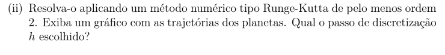

Primeiro, definimos o sistema de equações diferenciais ordinárias e a condição inicial conforme demonstrado na questão anterior. O RA utilizado é 236081, então as massas dos planetas são: m1 = 2, m2 = 1.

```r
#A função PVI é Z', note que Z' é função de Z e t.
PVIFunc <- function(t, Z){
  M1 = 2
  M2 = 1
  R = sqrt((Z[1] - Z[5])^2 + (Z[2] - Z[6])^2)
  EQ1 = (M2/R^3)*(Z[5] - Z[1])
  EQ2 = (M2/R^3)*(Z[6] - Z[2])
  EQ3 = (M1/R^3)*(Z[1] - Z[5])
  EQ4 = (M1/R^3)*(Z[2] - Z[6])
  vector = c(Z[3], Z[4], EQ1, EQ2, Z[7], Z[8], EQ3, EQ4)
  return(vector)
}

#As condições iniciais de posição e velocidade de ambos os planetas
Z = c(5,0,0,1,-3,0,0,-2)
```

O intervalo escolhido é de 0 a 100, com 500 passos, portanto, h = 100/500 = 0.2. É utilizada a função rk4sys do pacote pracma. A função aplica o método de runge kutta de quarta ordem para resolver o sistema de equações numericamente.

```r
A = 0
B = 100
N = 500

#resolução do sistema Z' = f. Os resultados são salvos em um dataframe
DF <- pracma::rk4sys(f = PVIFunc, a = A, b = B, y0 = Z, n = N)$y

#renomeando as colunas do dataframe para as respectivas variáveis obtidas.
names(DF) <- c('X1', 'Y1', 'Vx1', 'Vy1', 'X2', 'Y2', 'Vx2', 'Vy2')
```

```r
#criando um novo dataframe, filtrando as variáveis de posição e adicionando o tempo de 0 a 100 em 500 passos.
planetas <- data.frame(X1 = DF[,1], Y1 = DF[,2], X2 = DF[,5], Y2 = DF[,6], Tempo = seq(A, B, (B-A)/N))
```

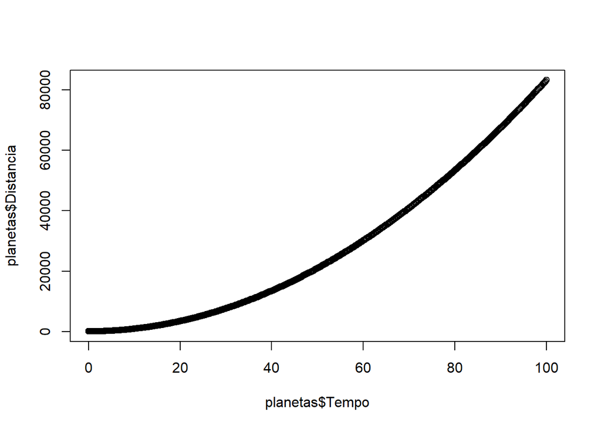

```r
#adicionando uma coluna distancia ao dataframe
planetas$Distancia <- (planetas[,1] - planetas[,3])^2 + (planetas[,2] - planetas[,4])^2

#plot da distância dos planetas pelo tempo
plot(planetas$Tempo, planetas$Distancia)
```

A trajetória dos planetas foi graficada como uma animação. Ela pode ser visualizada abrindo o arquivo .rmd no Rstudio e executando o chunk abaixo ou no arquivo orbita.gif incluso com o trabalho.

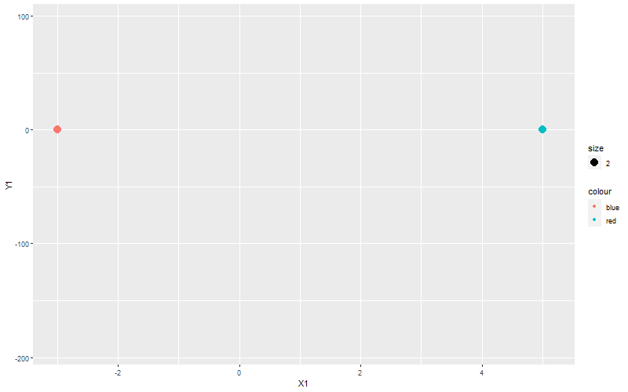

```r
lol <- ggplot(planetas)+
  geom_point(aes(x = X1, y = Y1, color = "red", size = 2))+
  geom_point(aes(x = X2, y = Y2, color = "blue", size = 2))+
  transition_time(Tempo)

animate(lol, duration = 4, fps = 20, width = 800, height = 500, renderer = gifski_renderer())
```

```r
anim_save("orbita.gif")
```

Os planetas tem velocidade inicial superior a velocidade de escape entre um e outro, por isso, a órbita não é realizada e eles se afastam indefinidamente. A propósito de curiosidade, se o primeiro planeta possuísse massa = 100 e o segundo planeta possuísse massa = 10, por exemplo, a órbita seria possível para as mesmas condições inciais. Abaixo, será construído um gráfico extra das posições dos planetas para este caso.

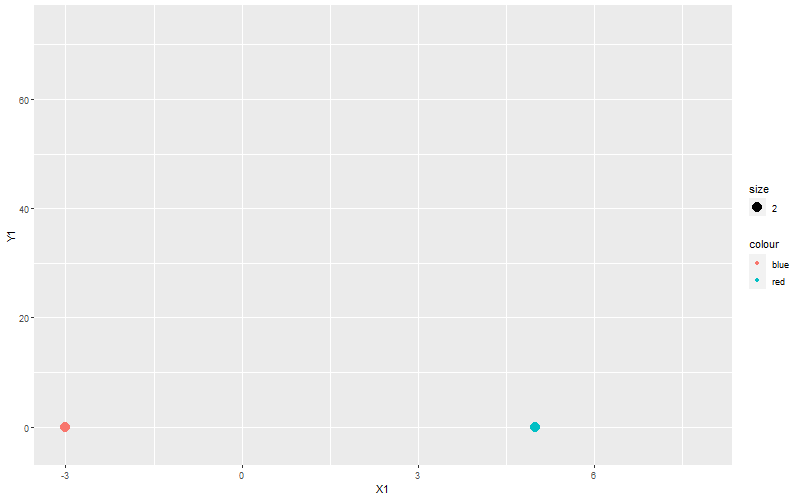

```r
PVIFunc_extra <- function(t, Z){
  M1 = 100
  M2 = 10
  R = sqrt((Z[1] - Z[5])^2 + (Z[2] - Z[6])^2)
  EQ1 = (M2/R^3)*(Z[5] - Z[1])
  EQ2 = (M2/R^3)*(Z[6] - Z[2])
  EQ3 = (M1/R^3)*(Z[1] - Z[5])
  EQ4 = (M1/R^3)*(Z[2] - Z[6])
  vector = c(Z[3], Z[4], EQ1, EQ2, Z[7], Z[8], EQ3, EQ4)
  return(vector)
}
Z_extra = c(5,0,0,1,-3,0,0,-2)
A_extra = 0
B_extra = 100
N_extra = 1000

DF_extra <- pracma::rk4sys(f = PVIFunc_extra, a = A_extra, b = B_extra, y0 = Z_extra, n = N_extra)$y

#renomeando as colunas do dataframe para as respectivas variáveis obtidas.
names(DF_extra) <- c('X1', 'Y1', 'Vx1', 'Vy1', 'X2', 'Y2', 'Vx2', 'Vy2')

planetas_extra <- data.frame(X1 = DF_extra[,1], Y1 = DF_extra[,2], X2 = DF_extra[,5], Y2 = DF_extra[,6], Tempo = seq(A_extra, B_extra, (B_extra-A_extra)/N_extra))

lol <- ggplot(planetas_extra)+
  geom_point(aes(x = X1, y = Y1, color = "red", size = 2))+
  geom_point(aes(x = X2, y = Y2, color = "blue", size = 2))+
  transition_time(Tempo)

animate(lol, duration = 8, fps = 20, width = 800, height = 500, renderer = gifski_renderer())
```

```r
anim_save("orbita_extra.gif")
```

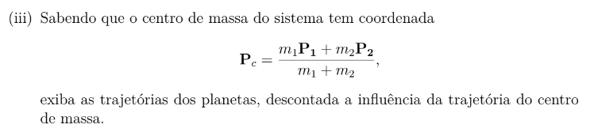

```r
planetas_ajustado = planetas
planetas_ajustado$XC = (1*planetas$X1 + 2*planetas$X2)/(1+2)
planetas_ajustado$YC = (1*planetas$Y1 + 2*planetas$Y2)/(1+2)
planetas_ajustado$X1 = planetas_ajustado$X1 - planetas_ajustado$XC
planetas_ajustado$X2 = planetas_ajustado$X2 - planetas_ajustado$XC
planetas_ajustado$Y1 = planetas_ajustado$Y1 - planetas_ajustado$YC
planetas_ajustado$Y2 = planetas_ajustado$Y2 - planetas_ajustado$YC
```

A animação pode ser visualizada no arquivo .rmd utilizando o chunk abaixo ou no arquivo orbita_ajustada.gif.

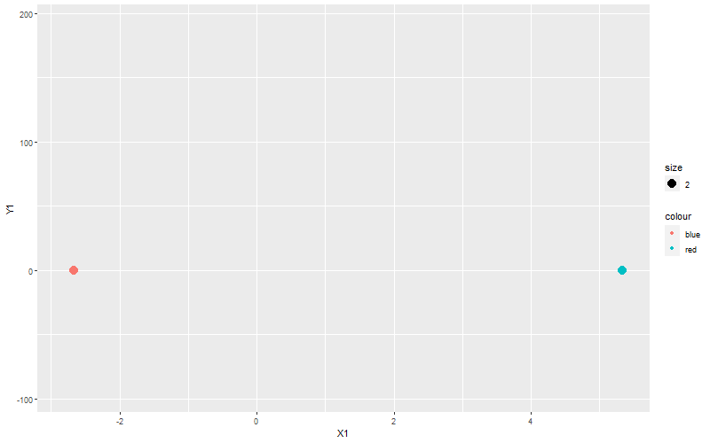

```r
lol <- ggplot(planetas_ajustado)+
  geom_point(aes(x = X1, y = Y1, color = "red", size = 2))+
  geom_point(aes(x = X2, y = Y2, color = "blue", size = 2))+
  transition_time(Tempo)

animate(lol, duration = 10, fps = 20, width = 800, height = 500, renderer = gifski_renderer())
```

```r
anim_save("orbita_ajustada.gif")
```

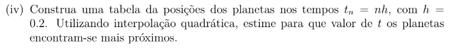

```r
head(planetas)
```

```
##         X1        Y1        X2         Y2 Tempo Distancia
## 1 5.000000 0.0000000 -3.000000  0.0000000   0.0  64.00000
## 2 4.999688 0.1999922 -2.999376 -0.3999844   0.2  64.34499
## 3 4.998757 0.3999381 -2.997514 -0.7998762   0.4  65.37989
## 4 4.997221 0.5997936 -2.994443 -1.1995871   0.6  67.10446
## 5 4.995105 0.7995185 -2.990210 -1.5990371   0.8  69.51832
## 6 4.992438 0.9990785 -2.984876 -1.9981571   1.0  72.62095
```

Para realizar a interpolação, são escolhidos os 3 primeiros valores da variável “distancia” dos planetas e utilizada a função lm (linear model) da base do R para retornar os coeficientes da melhor curva quadrática que passa pelos 3 pontos, como o número de pontos é uma unidade superior ao grau do polinômio, a curva ajustada será uma interpolação. Os coeficientes serão obtidos utilizando a função coef(), note que coef(x) retornará uma lista de valores, onde o primeiro elemento é o coeficiente da constante, o segundo elemento é o coeficiente linear e o terceiro elemento é o coeficiente quadrático. Pela equação do vértice da parábola, podemos utilizar os coeficientes de f(x) = ax² + bx + c, para encontrar o valor de x que resulta no mínimo da função (pois a > 0), a saber: A função é mínima quando x = -b/2a

```r
x <- lm(formula = planetas[1:3,6] ~ planetas[1:3,5] + I(planetas[1:3,5]^2))

-coef(x)[2]/(2*coef(x)[3])
```

```
## planetas[1:3, 5]
##    -1.162653e-05
```

É notável que -1,16*10^-5 é um valor negativo para o tempo, ou seja, não pertence ao domínio procurado. Portanto, o mínimo se dará na fronteira, logo, acontece quando t = 0.

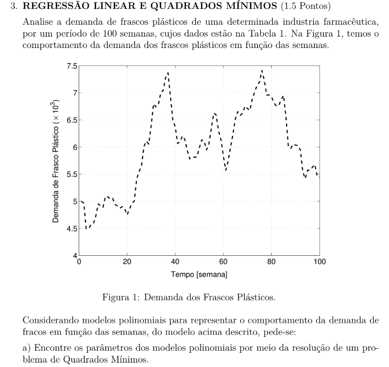

Os dados foram salvos em uma tabela no excel, para chamar o arquivo para o R, será usada a função read_excel do pacote readxl. Para corretamente carregar a tabela, é necessário utilizar o diretório correto no RStudio, como indicado no começo do arquivo .rmd.

Onde Beta é o vetor dos parâmetros do método dos mínimos quadrados.

X^(t) é a transposta de X. M^(-1) é a matriz inversa de M.

```r
#Carregando e ajustando o tipo das variáveis da tabela
dados <- readxl::read_excel("C:/R/CalculoNumerico/calculo_numerico.xlsx") %>% mutate(Demanda = as.numeric(Demanda), Semana = as.numeric(Semana))

tabela <- dados

#Criando colunas com as potências da variável preditora Semana.
for(n in 2:15){
  tabela <- tabela %>% mutate("X{n}" := Semana^n)
}

#Reordenando a tabela por conveniência.
tabela <- tabela %>% select(Semana, X2:X15, Demanda)

Parametros <- function(X, Y){
  Y = as.matrix(Y)
  X = as.matrix(X)
  #Cálculo do vetor Beta dos parâmetros, a função Solve retorna a inversa da matriz.
  Beta_hat <- solve(t(X)%*%X)%*%t(X)%*%Y
  return(Beta_hat)
}

#Print dos parâmetros para os polinômios de grau 1, 2 e 3.
for(m in c(1,2,3)){
  X = cbind(rep(1, nrow(tabela)), tabela[,1:m])
  Y = tabela[,16]
  print(Parametros(X, Y))
}
```

```
##                         Demanda
## rep(1, nrow(tabela)) 5.24315152
## Semana               0.01469126
##                            Demanda
## rep(1, nrow(tabela))  4.2286673469
## Semana                0.0743667964
## X2                   -0.0005908469
##                            Demanda
## rep(1, nrow(tabela))  4.497645e+00
## Semana                4.318220e-02
## X2                    1.772216e-04
## X3                   -5.069759e-06
```

São utilizados polinômios do grau até 3 pois a partir do grau 4 a matriz X^tX é computacionalmente singular, o que impede a realização da operação de inversão e também demonstra o mal condicionamento do problema apresentado.

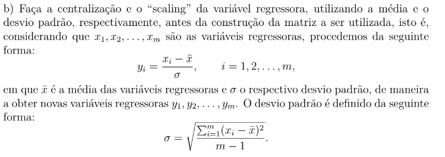

É criada uma nova tabela com o scaling dos dados, primeiro é adicionada a varíavel preditora Semana após o scaling.

```r
dadosscaling <- cbind(SemanaScaling = (dados$Semana - mean(dados$Semana))/(sqrt(var(dados$Semana))), Demanda = dados$Demanda) %>% as.data.frame()
```

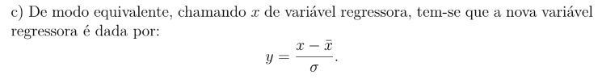

Então, é adicionada a variável resposta Demanda após o scaling.

```r
dadosscaling$Demanda <- (dadosscaling$Demanda - mean(dadosscaling$Demanda))/(sqrt(var(dadosscaling$Demanda)))
```

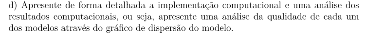

São feitos os respectivos gráficos: gráfico de Demanda por semana, o polinômio linear com seus respectivos parâmetros encontrados na questão anterior, assim como os polinômios quadráticos e cúbicos.

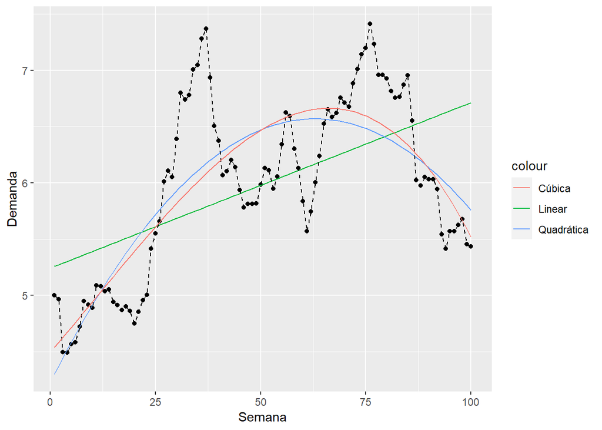

```r
#Usando os vetores de parâmetros encontrados anteriormente para as funções de grau 1, 2 e 3
Par1 = Parametros(cbind(rep(1, nrow(tabela)), tabela[,1:1]), tabela[,16])
Par2 = Parametros(cbind(rep(1, nrow(tabela)), tabela[,1:2]), tabela[,16])
Par3 = Parametros(cbind(rep(1, nrow(tabela)), tabela[,1:3]), tabela[,16])

dados %>% ggplot(aes(x = Semana, y = Demanda))+
  geom_point()+
  geom_line(linetype = 2)+
  stat_function(fun = function(x){Par1[1]+Par1[2]*x}, aes(color = "Linear"))+
  geom_line(linetype = 2)+
  stat_function(fun = function(x){Par2[1]+Par2[2]*x + Par2[3]*x^2}, aes(color = "Quadrática"))+
  geom_line(linetype = 2)+
  stat_function(fun = function(x){Par3[1]+Par3[2]*x + Par3[3]*x^2 + Par3[4]*x^3}, aes(color = "Cúbica"))
```

É notável que a predição ainda não é ideal, para conseguir computar os parâmetros de polinômios com graus maiores, utilizaremos a função lm (linear model) da base do R. Essa função utiliza a mesma técnica demonstrada anteriormente para o cálculo do vetor de parâmetros (coeficientes) do polinômio, porém é melhor trabalhada e otimizada, podendo calcular os parâmetros para graus até 14 antes de retornar NA’s.

Serão utilizados os coeficientes de grau 6 e 12.

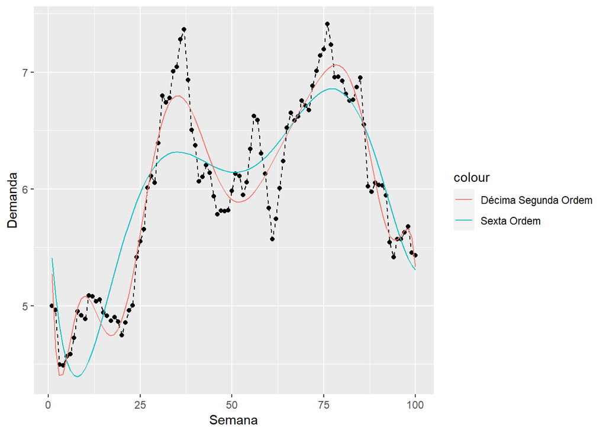

```r
#Obtenção dos coeficientes de grau 6 e 12
Par6 <- lm(Demanda ~ ., data = tabela[,c(1:6, 16)])$coefficients
Par12 <- lm(Demanda ~ ., data = tabela[,c(1:12, 16)])$coefficients

dados %>% ggplot(aes(x = Semana, y = Demanda))+
  geom_point()+
  geom_line(linetype = 2)+
  stat_function(fun = function(x){Par6[1]+Par6[2]*x + Par6[3]*x^2 + Par6[4]*x^3 + Par6[5]*x^4 + Par6[6]*x^5 + Par6[7]*x^6}, aes(color = "Sexta Ordem"))+
  geom_line(linetype = 2)+
  stat_function(fun = function(x){Par12[1]+Par12[2]*x + Par12[3]*x^2 + Par12[4]*x^3 + Par12[5]*x^4 + Par12[6]*x^5 + Par12[7]*x^6 + Par12[8]*x^7 + Par12[9]*x^8 + Par12[10]*x^9 + Par12[11]*x^10 + Par12[12]*x^11 + Par12[13]*x^12}, aes(color = "Décima Segunda Ordem"))
```

É notável como a aproximação das características da função aumenta consideravelmente com os graus do polinômio, tendo uma tendência geral modelada satisfatoriamente com um polinômio de grau 12.

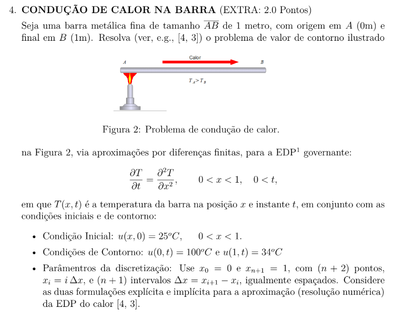

Primeiro, vamos resolver o problema de EDP governante por Euler explícito, para isso, definimos X de 0 a 1 com n = 100 e t de 0 a 1 com h = 100000. Será montada uma matriz onde cada coluna é uma das posições Xi (ordenadas) e cada linha é um dos instantes de tempo. O método consiste em definir uma linha u e sua linha anterior u_pass, assim:

u[i] = u_pass[i] + F(u_pass[i-1] - 2*u_pass[i] + u_pass[i+1])

Para i entre 1 e 100, onde u_pass[0] = u_pass[101] = 0. F é definido como dt/(dx)².

```r
#Definindo as variáveis
tempA = 100
tempB = 32
temp_inicial = 25

inicio_reta = 0
fim_reta = 1
passos_reta = 100
inicio_tempo = 0
fim_tempo = 1
passos_tempo = 100000

x = seq(inicio_reta, fim_reta, passos_reta)
dx = (fim_reta - inicio_reta)/passos_reta
t = seq(inicio_tempo, fim_tempo, passos_tempo)
dt = (fim_tempo - inicio_tempo)/passos_tempo
Par_F = dt/(dx^2)
u_pass = c(tempA, rep(temp_inicial, passos_reta-2), tempB)
u_inicial = u_pass

#Matriz final e lista auxiliar
matriz_explicito = data.frame(t(u_inicial))
lista = list()

#Loop para a criação das linhas
for(m in (1:(passos_tempo-1))){

  u = u_pass + Par_F*(lead(x = u_pass, n = 1, default = 0) - 2*u_pass + lag(x = u_pass, n = 1, default = 0))
  u[1] = tempA
  u[passos_reta] = tempB
  lista[[m]] <- u
  u_pass = u


}

#Criação da matriz final
matriz_explicito = do.call(rbind, lista)
matriz_explicito = rbind(u_inicial, matriz_explicito)
```

Podemos então fazer um gráfico para cada linha da matriz, representando a evolução da função do calor ao longo do tempo.

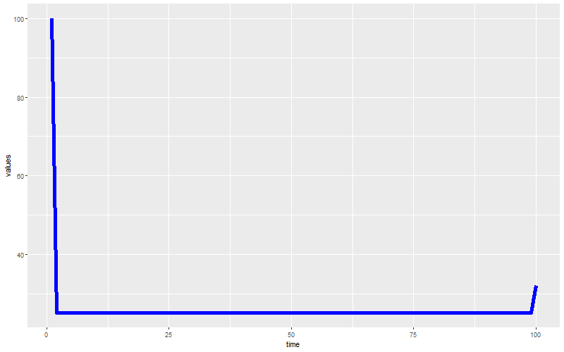

```r
#Modificando os dados para criar a animação com apenas algumas das linhas do dataframe.
values_by_1000 <- matriz_explicito[seq(1,nrow(matriz_explicito), 1000), ]
values_transpose <- t(values_by_1000) %>% as.data.frame()
names(values_transpose) <- 1:nrow(values_transpose)
values_long <- values_transpose %>% gather(key,values) %>% cbind(time = rep(1:nrow(values_transpose), ncol(values_transpose)))


animation <- ggplot(values_long, aes(x = time, y = values))+
                     geom_line(color = 'blue', size = 2)+
                     transition_time(as.numeric(key))

animate(animation, duration = 4, fps = 50, width = 800, height = 500, renderer = gifski_renderer())
```

```r
anim_save("equacao_calor_explicito.gif")
```

```r
#Criando a matriz A na variável 'sistema'.
sistema = (1+2*Par_F)*diag(passos_reta)
semi_diag_sup = -Par_F*lead(diag(passos_reta), default = 0)
semi_diag_und = -Par_F*lag(diag(passos_reta), default = 0)
sistema = sistema + semi_diag_sup + semi_diag_und
sistema[1,] = c(1, rep(0, passos_reta-1))
sistema[passos_reta,] = c(rep(0, passos_reta-1), 1)
head(sistema)
```

[output not shown]

[output cut: 48 more lines]

Definida a matriz, o método consiste em, para cada linha, definir b como o vetor igual a linha anterior porém o primeiro e o último elemento são trocados pela temperatura em x = 0 e x = 100, respectivamente. Após isso, a linha é u é igual ao resultado do sistema de equações Ax = b. Resolvendo o sistema para cada passo de tempo, temos a evolução de cada ponto e, assim, a resolução numérica do problema.

A função Solve da base do R retorna os valores da resolução de um sistema linear primeiro realizando a fatoração LU usando pivoteamento parcial e troca de linhas e depois resolvendo por substituição.

```r
#Iterando o método para cada instante de tempo
u_pass = u_inicial
lista = list()

for(n in 1:(passos_tempo-1)){
  b = c(tempA, u_pass[2:(passos_reta-1)], tempB)
  #A função Solve resolve o sistema linear Ax = B utilizando métodos utilizando mecanismos do código do LAPACK.
  u = solve(sistema, b)
  lista[[n]] = u
  u_pass = u
}

matriz_implicito = do.call(rbind, lista)
matriz_implicito = rbind(u_inicial, matriz_implicito)
```

Segue a evolução da equação diferencial em função do tempo.

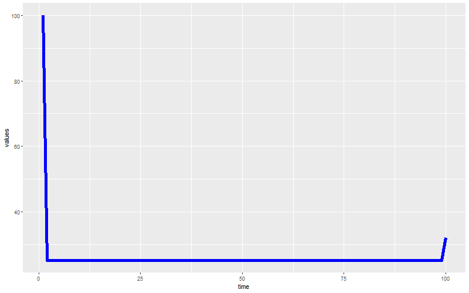

```r
#Ajustando a matriz para a animação e separando apenas as linhas a serem utilizadas.
values_by_1000 <- matriz_implicito[seq(1,nrow(matriz_implicito), 1000), ]
values_transpose <- t(values_by_1000) %>% as.data.frame()
names(values_transpose) <- 1:nrow(values_transpose)
values_long <- values_transpose %>% gather(key,values) %>% cbind(time = rep(1:nrow(values_transpose), ncol(values_transpose)))


animation <- ggplot(values_long, aes(x = time, y = values))+
                     geom_line(color = 'blue', size = 2)+
                     transition_time(as.numeric(key))

animate(animation, duration = 4, fps = 50, width = 800, height = 500, renderer = gifski_renderer())
```

```r
anim_save("equacao_calor_implicito.gif")
```

O “pulo súbito” no começo da animação pode ser explicado pela sabida velocidade de propagação infinita da equação do calor, o que significa que pontos no interior da barra tem sua temperatura afetada instantaneamente pelas condições ao seu redor, para qualquer t > 0.

Referências:

[1] M. A. Gomes Ruggiero, V. L. da Rocha Lopes. Cálculo Numérico - Aspectos Teóricos e Computacionais, 2a edição, Editora Pearson, 1997.

[2 ]W., Sanford. Applied Linear Regression. 2nd ed. New York, Wiley, 1985.